# IA para Científicos Sociales

Sesión 5.2: Ética, sesgo y regulación

Danilo Freire

danilofreire@gmail.com

Department of Data and Decision Sciences  
Emory University

# Ética, sesgo y regulación

## Repaso: ya sabemos usar la IA

**Esta semana aprendimos a usarla**

- Clasificación y regresión, clustering, análisis de texto
- LLMs para anotación, extracción y generación de datos, con `ellmer` y `quallmer`
- Y a validar todo contra un estándar conocido

**Recién, en la sesión 5.1**

- Modelos de pesos abiertos, cuantizados para entrar en una laptop
- Ollama y el Modelfile: un codificador congelado y reproducible
- La motivación era ética: datos sensibles que no pueden salir de la máquina

**Ahora: las preguntas difíciles**

- ¿Estos sistemas son justos?
- ¿De dónde viene el sesgo?
- ¿Cómo se mide la equidad?
- ¿Se puede arreglar?
- ¿Quién decide qué es justo?
- ¿Quién protege la privacidad de las personas en los datos?
- ¿Cómo se regula todo esto?

Saber usar una herramienta y saber cuándo no usarla son dos cosas distintas

## Agenda de la sesión

**Sesgo: qué es y de dónde viene**

- Una historia para empezar
- Cinco usos de la palabra “sesgo”
- Una taxonomía del sesgo algorítmico
- Bucles de retroalimentación
- Casos en América Latina

**Medir la equidad**

- Las métricas, con un ejemplo concreto
- El teorema de imposibilidad
- Cuatro tensiones sin solución limpia
- Detección, mitigación y el caso COMPAS

**Privacidad**

- Escala, inferencia y persistencia
- El caso Clearview AI
- Del GDPR a la Ley 18.331

**Regulación y cierre**

- El EU AI Act, EE.UU. y América Latina
- Qué pueden hacer los investigadores

# Una historia para empezar

## Robert Williams, Detroit, 2020

- Robert Julian-Borchak Williams fue arrestado frente a su familia en Detroit
- Acusado de robar relojes, detenido 30 horas
- Luego liberado: persona equivocada

**¿Qué pasó?**

- Un sistema de reconocimiento facial comparó su foto del carnet con imágenes borrosas de vigilancia
- El algoritmo se equivocó
- Robert es afroamericano. El reconocimiento facial tiene tasas de error más altas con rostros de piel oscura
- No fue un error de software. Así fue construido el sistema

[figure not shown]

El caso de Robert Williams

Fuente: [ACLU](https://www.aclumich.org/news/i-was-wrongfully-arrested-because-facial-recognition-technology-it-shouldnt-happen-anyone-else/); [NPR (2020)](https://www.npr.org/2020/06/24/882683463/the-computer-got-it-wrong-how-facial-recognition-led-to-a-false-arrest-in-michig)

# ¿Qué es el sesgo algorítmico?

## “Sesgo”: una palabra, cinco usos

La palabra aparece en contextos distintos y conviene separarlos antes de seguir:

| Uso | Qué significa | Ejemplo |
| --- | --- | --- |
| Estadístico | Desviación sistemática del valor verdadero | Una muestra que sobrerrepresenta a Montevideo |
| Cognitivo | Atajos mentales de las personas | Confirmar lo que ya creíamos |
| Cultural | Supuestos aprendidos de la sociedad | Asociar profesiones con géneros |
| Histórico | Desigualdades pasadas registradas en datos | Décadas de contrataciones discriminatorias |
| Algorítmico | Resultados sistemáticamente injustos de un sistema | El tema de hoy |

- Los cuatro primeros se filtran en el quinto: los datos cargan los sesgos estadísticos, cognitivos, culturales e históricos de quienes los generaron
- Por eso “el algoritmo es neutral” es un argumento que no se sostiene

## El sesgo es la IA reflejándonos

**En IA, sesgo suele significar:**

> Un sistema que produce resultados sistemáticamente injustos para ciertos grupos de personas.
- La IA aprende de datos generados por humanos
- Si los humanos decidieron de forma sesgada, la IA aprende ese patrón
- Y puede amplificarlo a escala

**Ejemplo: word embeddings** ([Bolukbasi et al., 2016](https://arxiv.org/abs/1607.06520))

- “Hombre” es a “Doctor” como “Mujer” es a… “Enfermera”
- La IA recogió nuestro propio sexismo de millones de textos
- Si el sesgo viene de nosotros, ¿eso hace a la IA menos responsable, o más?

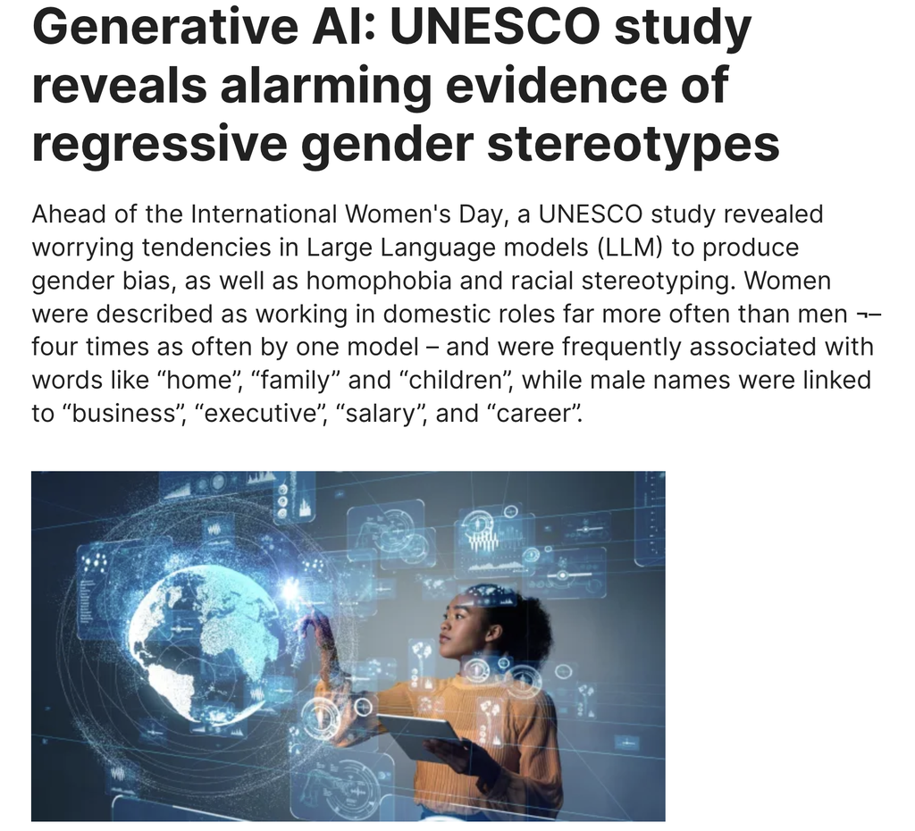

La IA hereda sesgos humanos

Fuente: [UNESCO](https://www.unesco.org/en/articles/generative-ai-unesco-study-reveals-alarming-evidence-regressive-gender-stereotypes)

La parte difícil no es detectar diferencias, es decidir qué cuenta como “injusto”.

## Discusión rápida: ¿qué riesgo prefieren?

Una universidad decide admisiones. Hay dos opciones:

**Opción A: un comité humano**

- Sesgos inconsistentes: dependen de quién lea su carpeta, de su humor, de la hora
- Difíciles de detectar, imposibles de auditar a escala

**Opción B: un algoritmo**

- Sesgos sistemáticos: el mismo error, para todos los casos parecidos, siempre
- Pero medibles, auditables y, en principio, corregibles

**Para discutir (2 min)**

1. ¿Cuál preferirían si fueran el postulante?
2. ¿Y si fueran la universidad?
3. ¿Cambia algo que el error sistemático se pueda demostrar ante un juez y el humano no?

No hay respuesta correcta: la pregunta revela qué tipo de injusticia nos resulta más tolerable.

## Una taxonomía del sesgo

| Tipo de sesgo | Cuándo ocurre | Ejemplo |
| --- | --- | --- |
| Histórico | Decisiones pasadas codificadas en datos | IA de contratación de Amazon penaliza CVs “de mujeres” |
| Representación | Grupos subrepresentados | 35% de error en mujeres de piel oscura |
| Medición | Proxies para conceptos no medibles | Código postal como proxy de solvencia |
| Agregación | Tratar grupos diversos como uno | Un modelo “global” falla localmente |
| Evaluación | Benchmarks no representativos | Probado en España, usado en Argentina |
| Despliegue | Modelo usado en contexto equivocado | Modelo de 2015 aplicado en 2025 |

- El sesgo puede entrar en cualquier etapa: recolección, etiquetado, entrenamiento, evaluación, despliegue, uso
- Una idea para llevarse: datos precisos no son lo mismo que datos justos
- Ejemplos detallados de cada tipo

## Bucles de retroalimentación

Cuando las predicciones del algoritmo influyen en los datos que lo entrenarán después.

**Ejemplo: vigilancia predictiva** ([Lum e Isaac, 2016](https://doi.org/10.1111/j.1740-9713.2016.00960.x))

1. El algoritmo predice zonas de alto crimen con datos de arrestos pasados
2. La policía patrulla esas zonas más intensamente
3. Más patrullas → más arrestos (haya o no más crimen)
4. Los nuevos datos confirman la predicción
5. El algoritmo se vuelve más confiado en un patrón sesgado

El algoritmo crea evidencia para sus propias predicciones.

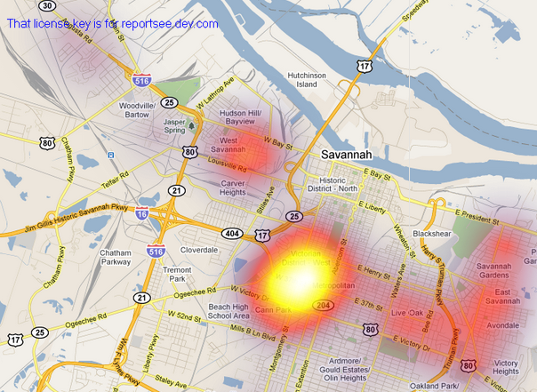

Bucle de retroalimentación

Fuente: [SpotCrime](https://blog.spotcrime.com/2011/06/savanna-ga-heat-map.html)

**Otros bucles:**

- Denegar crédito → peor historial → más denegaciones
- Filtros de CVs → equipo homogéneo → más sesgo en los datos

## Casos de sesgo en América Latina

**Brasil: reconocimiento facial policial**

- El Carnaval de Salvador (2019) inauguró los arrestos por reconocimiento facial en Brasil
- La [Rede de Observatórios da Segurança](https://observatorioseguranca.com.br/) relevó los casos de 2019: el 90,5% de los detenidos por estos sistemas eran personas negras
- El mismo sesgo de representación que vimos con Robert Williams, a escala regional

**Argentina: predecir embarazos adolescentes**

- Salta (2018): un sistema de Microsoft y el gobierno provincial decía predecir qué adolescentes quedarían embarazadas a partir de datos socioeconómicos
- Aplicado sobre poblaciones pobres, sin transparencia ni evaluación; el [Laboratorio de IA Aplicada de la UBA](https://liaa.dc.uba.ar/es/sobre-la-prediccion-automatica-de-embarazos-adolescentes/) mostró errores metodológicos graves ([Wired, 2022](https://www.wired.com/story/argentina-algorithms-pregnancy-prediction/))

**Chile: Sistema Alerta Niñez**

- Modelo que predice riesgo de vulneración de derechos de niños usando datos familiares y socioeconómicos
- Críticas de [Derechos Digitales](https://www.derechosdigitales.org/) por estigmatización: los falsos positivos se concentran en familias pobres, las más presentes en los registros estatales

**Colombia: reconocimiento facial en el transporte**

- Detección de evasores en TransMilenio (Bogotá)
- [Fundación Karisma](https://web.karisma.org.co/) documentó preocupaciones por vigilancia masiva y falta de consentimiento

Los mismos problemas del norte global se replican en la región, a menudo con menos protecciones y menos prensa.

# Medir la equidad

## ¿Cómo medimos si un modelo es justo?

Un ejemplo concreto: un banco usa un modelo para aprobar créditos. Se presentan 100 personas del Grupo A y 100 del Grupo B. Sabemos (después) quiénes pagaron.

| Métrica | La pregunta, en simple | En el ejemplo |
| --- | --- | --- |
| Paridad demográfica | ¿Aprobamos a los dos grupos por igual? | A: 50 de 100 aprobados. B: 30 de 100. No hay paridad |
| Igualdad de oportunidades | Entre los que sí pagan, ¿aprobamos por igual? | De los buenos pagadores, A: 80% aprobados. B: 60%. Hay buenos pagadores de B que el modelo rechaza más |
| Calibración | Un “70% de probabilidad de pago”, ¿vale lo mismo? | De quienes recibieron un score de 70, ¿pagan ~70 de cada 100 en ambos grupos? |

- La primera mira los resultados (quién recibe el sí)
- La segunda mira los errores (a quién le erramos)
- La tercera mira el significado del score (si el número es honesto)

Las tres suenan razonables. Cada una captura una noción distinta de “justo”, y elegir una es elegir a quién proteger. La próxima diapositiva muestra que no se pueden tener todas.

## El teorema de imposibilidad

**Tres criterios de equidad (simplificados):**

1. Calibración: a igual puntuación, resultados similares entre grupos
2. Igualdad de falsos positivos: misma tasa de ser señalado por error
3. Igualdad de falsos negativos: misma tasa de ser ignorado por error

**El teorema** ([Chouldechova, 2017](https://doi.org/10.1089/big.2016.0047); [Kleinberg et al., 2016](https://arxiv.org/abs/1609.05807)):

> Si las tasas base difieren entre grupos, no se pueden satisfacer los tres criterios a la vez.

**En simple**: si el Grupo A reincide al 40% y el B al 20%, hay que elegir qué tipo de error igualar.

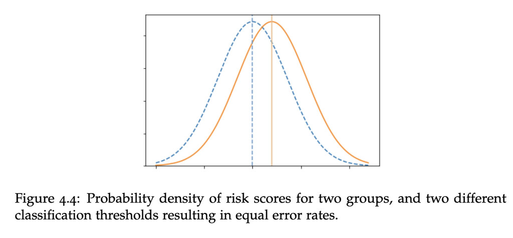

Teorema de imposibilidad

Fuente: [Fairness and Machine Learning Book](https://fairmlbook.org/)

No existe una solución matemáticamente “justa”. Ningún algoritmo decide qué errores importan más.

## ¿Quién define “justo”?

| Definición | Prioriza | Desventaja |
| --- | --- | --- |
| Igual trato | Consistencia | Ignora el contexto |
| Igualdad de resultados | Equidad | Puede requerir trato diferenciado |
| Igual tasa de error | Paridad entre grupos | Puede sacrificar precisión |
| Calibración | Precisión individual | Oculta disparidades |

- No existe un valor por defecto neutral
- Quien elige la definición de equidad determina quién se beneficia
- Decir “solo usamos los datos” es, en sí mismo, una elección
- Es una pregunta política y moral, no técnica

Actividad: el dilema del préstamo

## Cuatro tensiones sin solución clara

Aun después de elegir una definición, quedan trade-offs que ningún ajuste técnico elimina:

| Tensión | El dilema |
| --- | --- |
| Precisión vs equidad | Imponer una restricción de equidad suele bajar la accuracy global. ¿Cuánta precisión vale una mejora en paridad? |
| Individual vs grupal | Tratar igual a individuos similares puede producir disparidades entre grupos, y corregir al grupo puede tratar distinto a individuos similares |
| Transparencia vs manipulación | Publicar los criterios permite auditarlos, y también permite “jugarle” al sistema |
| Corto vs largo plazo | Una corrección hoy cambia los datos de mañana: los bucles de retroalimentación también funcionan a favor |

Cada tensión es una decisión de diseño que alguien toma, la haga explícita o no.

## Un ejemplo: el umbral de crédito

- Un modelo predice la probabilidad de que cada persona pague el préstamo
- Aprobamos si la probabilidad supera un umbral
- El Grupo B tiene una tasa de repago histórica más baja (por desventaja económica, no por capacidad)
- Con el mismo umbral para todos, el Grupo B se aprueba mucho menos
- Para igualar la aprobación, habría que bajar su umbral. Pero eso aprueba más préstamos que no se pagarán: sube su tasa de falsos positivos

No se puede igualar todo a la vez. El umbral es una elección de valores.

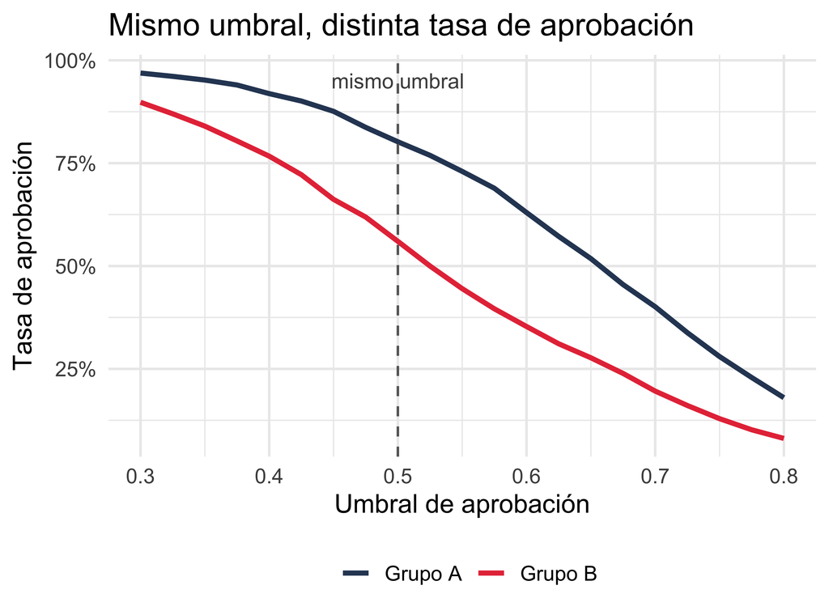

## Detección y mitigación

**Detectar: tres pasos**

1. Definir los grupos protegidos (género, etnicidad, edad…). A veces solo hay proxies
2. Calcular métricas por grupo: tasa positiva, TPR, FPR, valor predictivo
3. Comparar entre grupos. Regla del 80%: si un grupo recibe menos del 80% de la tasa del otro, hay disparidad

**Herramientas**

| Herramienta | Lenguaje |
| --- | --- |
| [fairmodels](https://fairmodels.drwhy.ai/) | R |
| AI Fairness 360, Fairlearn, Aequitas | Python |

**Mitigar: tres momentos**

- Pre-procesamiento: cambiar los datos (rebalancear, quitar variables sensibles)
- In-procesamiento: cambiar el entrenamiento (restricciones de equidad en la pérdida)
- Post-procesamiento: cambiar las predicciones (umbrales por grupo)

Ninguna técnica es perfecta: la mitigación siempre implica trade-offs.

El laboratorio de hoy hace una auditoría completa con `fairmodels` sobre datos de crédito.

## El caso COMPAS

**¿Qué es COMPAS?**

- Sistema de scoring de riesgo de reincidencia usado en EE.UU. para fianza, sentencia y libertad condicional

**El análisis de ProPublica (2016):**

- Tasas de falsos positivos desiguales:
  - Negros: 44,9% señalados como alto riesgo pero no reincidieron
  - Blancos: 23,5% en la misma situación
- Conclusión: el sistema es racialmente sesgado

**La respuesta de Northpointe:**

- COMPAS está calibrado: una puntuación de 7 significa lo mismo para ambos grupos
- Si las tasas base difieren, no se pueden igualar FPR y calibración a la vez
- El teorema de imposibilidad en acción

**¿Quién tiene razón?** Ambos. El debate no es sobre hechos sino sobre valores: ¿qué error importa más?

Fuente: [ProPublica (2016)](https://www.propublica.org/article/machine-bias-risk-assessments-in-criminal-sentencing)

# Privacidad y datos personales

## La IA cambia el problema de la privacidad

Tres cosas que antes no pasaban:

- Escala: recolectar y procesar datos de millones de personas cuesta casi nada
- Inferencia: el modelo deduce lo que nunca contaron. Los “me gusta” predicen orientación política; las compras, un embarazo; el celular, síntomas de depresión
- Persistencia: lo que entró a un dataset o a un modelo entrenado es muy difícil de borrar. Los LLMs pueden memorizar y filtrar texto de entrenamiento, incluyendo nombres y contactos ([Carlini et al., 2021](https://arxiv.org/abs/2012.07805))

**El caso clásico de inferencia**

La cadena Target (EE.UU.) identificó el embarazo de una adolescente por sus patrones de compra y mandó cupones de bebé a su casa, antes de que su padre lo supiera ([New York Times, 2012](https://www.nytimes.com/2012/02/19/magazine/shopping-habits.html)).

El problema no es solo qué datos entregamos, sino qué se puede inferir de ellos. El consentimiento que firmamos rara vez cubre eso.

## Clearview AI: su cara ya está en la base

- Una empresa raspó más de 30 mil millones de fotos de Facebook, Instagram y LinkedIn, sin consentimiento de nadie
- Vendió la búsqueda por rostro a más de 2.400 agencias policiales de EE.UU.
- Revelado por el [New York Times (2020)](https://www.nytimes.com/2020/01/18/technology/clearview-privacy-facial-recognition.html); la ACLU lo describió como poner a todo el mundo en una rueda de reconocimiento perpetua
- Multas: 20 millones de euros en Francia, 20 en Italia, 30,5 en Países Bajos; Reino Unido, Australia y Canadá ordenaron borrar los datos

**Por qué importa para esta clase**

- Es el sistema que cierra el círculo con Robert Williams: el reconocimiento facial policial se alimenta de datos obtenidos así
- Y muestra el límite de la autorregulación: la empresa solo cambió cuando llegaron demandas y multas

“Estaba disponible públicamente” no es lo mismo que “consentí este uso”. Eso aplica también a los datos que usamos en investigación.

## Protección de datos: del GDPR a la Ley 18.331

**El modelo europeo (GDPR, 2018)**

- Principios: minimización (recolectar solo lo necesario), limitación de propósito, plazos de conservación
- Derechos: acceso, rectificación, olvido, portabilidad, y a no ser objeto de decisiones puramente automatizadas con efectos importantes (artículo 22)

**Uruguay llegó antes que la región**

- La [Ley 18.331](https://www.impo.com.uy/bases/leyes/18331-2008) (2008) y la URCDP
- Uruguay es de los pocos países con adecuación reconocida por la UE: su protección se considera equivalente

**Donde la IA tensiona la ley**

| El derecho | El problema técnico |
| --- | --- |
| Minimización | Los LLMs quieren todos los datos |
| Olvido | “Desentrenar” un modelo es casi imposible |
| Explicación | Las cajas negras no se explican solas |

Para investigadores, la defensa más práctica ya la vimos en la sesión 5.1: con un modelo local, los datos de los participantes nunca se transfieren a un tercero.

# Regulación de la IA

## EU AI Act (2024)

**Primera ley integral sobre IA en el mundo.** Clasifica los sistemas por nivel de riesgo:

| Nivel | Ejemplos | Requisitos |
| --- | --- | --- |
| Inaceptable | Scoring social masivo, vigilancia biométrica en tiempo real | Prohibido |
| Alto riesgo | Salud, justicia, empleo, crédito, educación | Auditoría y registro |
| Riesgo limitado | Chatbots, deepfakes | Transparencia |
| Riesgo mínimo | Filtros de spam, videojuegos | Sin restricciones |

**Multas:** hasta 35 millones de euros o 7% de la facturación global

**Aplicación:** gradual entre 2024 y 2027

**Para investigadores:** los sistemas de IA para investigación suelen estar exentos, pero si se despliegan, aplica la regulación.

Fuente: [European Commission](https://digital-strategy.ec.europa.eu/en/policies/regulatory-framework-ai)

## Regulación: EE.UU. y América Latina

**Estados Unidos: fragmentado**

- Sin ley federal integral, enfoque sectorial (FDA, FTC, EEOC)
- Estados: Nueva York exige auditoría de IA en contratación (2023); California, Colorado avanzan
- La orden ejecutiva de Biden (2023) fue revocada en 2025

**América Latina: en construcción**

- Uruguay: Ley 18.331 de datos, Estrategia Nacional de IA (2019), bien posicionado pero sin ley específica
- Brasil: LGPD (2018) y PL 2338/2023, inspirado en el EU AI Act
- Chile: política nacional de IA (2021) y ley pionera de neuroderechos
- Desafío común: brecha entre legislación y aplicación

La autorregulación de la industria no es suficiente: sin poder de aplicación y con conflicto de intereses.

Estándares y autorregulación

## ¿Qué pueden hacer los investigadores?

**En su propia investigación**

- Documentar las limitaciones del modelo
- Reportar métricas por subgrupos, no solo el promedio
- Transparentar datos y código
- Considerar quién puede ser afectado
- Evitar claims exagerados de equidad

**En la sociedad**

- Auditar sistemas existentes y comunicar hallazgos
- Participar en los debates de política pública

**Preguntas para cada proyecto**

1. ¿Qué daños podría causar el sistema?
2. ¿Quiénes son los grupos afectados?
3. ¿Cómo mediría si es justo?
4. ¿Qué variables son proxies de atributos sensibles?
5. ¿Quién definió el éxito?
6. ¿Hay supervisión humana y mecanismo de apelación?

La ética no es un paso final; es parte del diseño desde el inicio.

¿Es solucionable el sesgo? Optimistas y escépticos

## Resumen de la sesión

**Sesgo**

- La IA hereda sesgos humanos de los datos
- Seis tipos, en cualquier etapa del ciclo
- Los bucles de retroalimentación lo amplifican
- América Latina replica los problemas con menos protecciones

**Medición**

- Paridad, oportunidades, calibración: cada una protege a alguien distinto
- El teorema de imposibilidad: no se pueden tener todas a la vez
- Y aun eligiendo, quedan cuatro tensiones de diseño

**Privacidad**

- Escala, inferencia y persistencia cambian el problema
- Clearview AI: “público” no es “consentido”
- GDPR y Ley 18.331; el modelo local como defensa práctica

**Regulación**

- EU AI Act: clasificación por riesgo; EE.UU. fragmentado; América Latina en construcción
- La autorregulación no alcanza

**Para llevarse**

- La equidad es una elección de valores
- Los investigadores tienen responsabilidad sobre lo que construyen

Ahora: el laboratorio 9, con el modelo local y la auditoría de equidad. Después, sus propuestas de investigación

# Vamos al laboratorio 🤓

# Apéndice

## Sesgo histórico: el pasado codificado

La discriminación pasada se incorpora a los datos, aunque reflejen con precisión el mundo de ese momento.

**El caso de Amazon (2018)** ([Reuters](https://www.reuters.com/article/world/insight-amazon-scraps-secret-ai-recruiting-tool-that-showed-bias-against-women-idUSKCN1MK0AG/)):

- IA para filtrar CVs, entrenada con 10 años de contrataciones pasadas
- Esas contrataciones eran mayoritariamente masculinas
- La IA aprendió a penalizar CVs que mencionaran “mujeres”
  - “Capitana del club de ajedrez femenino” → penalizada
- Amazon desechó la herramienta

Datos precisos ≠ datos justos.

[figure not shown]

Amazon

Fuente: [Reuters](https://www.reuters.com/article/world/insight-amazon-scraps-secret-ai-recruiting-tool-that-showed-bias-against-women-idUSKCN1MK0AG/)

Volver

## Sesgo de representación: ¿quién falta?

Cuando ciertos grupos están subrepresentados, el modelo funciona mal para ellos.

**Reconocimiento facial** ([Buolamwini y Gebru, 2018](https://proceedings.mlr.press/v81/buolamwini18a.html)):

- Hombres de piel clara: 0,8% de error
- Mujeres de piel oscura: 34,7% de error
- Un rendimiento 43 veces peor para un grupo

**Asistentes de voz**: entrenados con acentos angloamericanos, fallan más con hablantes no nativos y voces de mujeres.

Si no están en los datos, el modelo no tiene nada que aprender sobre ustedes.

[figure not shown]

Reconocimiento facial

Fuente: [Joy Buolamwini](https://medium.com/@Joy.Buolamwini/)

Volver

## Sesgo de medición: proxies problemáticos

Usar un proxy medible para algo que importa, pero que no funciona igual para todos.

**Código postal como proxy crediticio**

- Los bancos no pueden usar raza para decidir préstamos
- Pero pueden usar código postal, que correlaciona con raza por segregación residencial
- Resultado: una variable “neutral” que codifica raza

| Lo que queremos | Proxy usado | Problema |
| --- | --- | --- |
| Inteligencia | Tests estandarizados | Refleja acceso a preparación |
| Necesidad de salud | Gasto pasado | Refleja barreras de acceso |

Se puede quitar la raza de los datos y aun así terminar con un modelo racialmente sesgado ([Obermeyer et al., 2019](https://doi.org/10.1126/science.aax2342)).

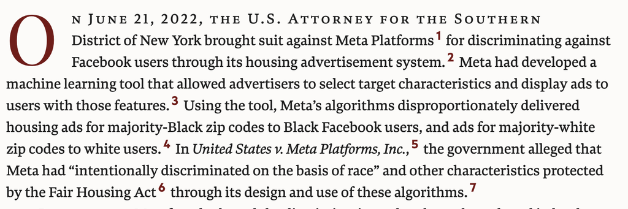

Proxies

Fuente: [Harvard Law Review](https://harvardlawreview.org/print/vol-138/resetting-antidiscrimination-law-in-the-age-of-ai/)

Volver

## Sesgo de agregación y de despliegue

**Agregación**: tratar a grupos diversos como homogéneos.

- Modelos de riesgo de diabetes entrenados con poblaciones europeas usan la HbA1c, que funciona distinto en otras poblaciones → subdiagnóstico
- Un modelo de satisfacción democrática europeo puede fallar en América Latina: las escalas de encuesta significan cosas distintas entre culturas

**Evaluación y despliegue**: probar o usar el modelo en el contexto equivocado.

| Entrenado en… | Usado en… | Problema |
| --- | --- | --- |
| España | Argentina | “boludo”, voseo |
| EE.UU. | Uruguay | Diferencias culturales |
| 2015 | 2025 | Cambios temporales |
| Texto formal | Redes sociales | Registro distinto |

El rendimiento no viaja bien entre contextos.

Volver

## Definiciones formales de las métricas

**Paridad demográfica**

$$P(\hat{Y} = 1 \mid A = a) = P(\hat{Y} = 1 \mid A = b)$$

Misma tasa de resultados positivos entre grupos. Garantiza representación, pero ignora las tasas base.

**Igualdad de oportunidades**

$$P(\hat{Y} = 1 \mid Y = 1, A = a) = P(\hat{Y} = 1 \mid Y = 1, A = b)$$

Entre quienes merecen el resultado, mismo TPR. Requiere conocer el resultado real.

**Calibración**

$$P(Y = 1 \mid \hat{Y} = p, A = a) = p$$

Una predicción de p% significa lo mismo para todos los grupos. Hace las predicciones interpretables, pero no garantiza igualdad de errores.

COMPAS estaba calibrado pero tenía falsos positivos desiguales por raza. Las métricas chocan entre sí.

Volver

## ¿Es solucionable el sesgo en la IA?

**Los optimistas**

- Es un problema técnico con soluciones técnicas: mejores datos, algoritmos y auditorías
- La IA puede ser menos sesgada que los humanos: es consistente y se puede auditar

> “Un algoritmo sesgado se puede reentrenar. Un gerente de contratación sesgado es más difícil de arreglar.”

**Los escépticos**

- El sesgo refleja problemas sociales que no se arreglan con código
- Hablar de “IA justa” distrae de las causas raíz
- ¿Quién define la equidad? Generalmente quienes ya tienen poder

> “No se arregla un mercado inmobiliario discriminatorio ajustando un modelo de scoring crediticio.”

¿Dónde se ubican ustedes?

Volver

## Autorregulación y estándares

**Estándares técnicos**

- ISO/IEC 42001: gestión de IA
- NIST AI RMF: gestión de riesgos
- IEEE P7000: diseño ético

**Principios de la industria**

- Google AI Principles, Microsoft Responsible AI, Anthropic responsible scaling policy
- Iniciativas académicas: Montreal (2018), OECD (2019)

**Críticas**

- Sin poder de aplicación
- Conflicto de intereses: quien desarrolla, audita
- Principios vagos y no vinculantes (“ética-washing”)
- Las empresas abandonan compromisos cuando son inconvenientes

Consenso emergente: se necesita regulación vinculante con supervisión externa.

Volver

## Actividad: el dilema del préstamo

**Están diseñando un algoritmo de aprobación de préstamos**

Los datos muestran:

- Grupo A: 80% paga los préstamos
- Grupo B: 60% paga (por desventaja económica histórica)

Elijan UNO:

1. Mismo umbral para todos (70%) → más rechazos del Grupo B
2. Misma tasa de aprobación → más impagos y riesgo
3. Mismo trato a los buenos pagadores → distintas tasas de aprobación

**Para discutir (10 min):**

- ¿Cuál enfoque es “más justo”?
- ¿Quién se beneficia y quién se perjudica con cada uno?
- ¿Cambia su respuesta si la menor tasa del Grupo B se debe a discriminación, no a capacidad?
- ¿El algoritmo debería corregir la injusticia histórica, o solo no perpetuarla?

Debatan en grupos de 3-4 y presenten su decisión.

Volver

## Actividad: identificar el sesgo

Una universidad uruguaya quiere predecir qué estudiantes tienen riesgo de deserción y ofrecerles apoyo temprano.

El modelo usa:

- Notas del primer semestre
- Asistencia a clases
- Barrio de residencia
- Si trabaja además de estudiar
- Tipo de liceo (público/privado)

Tiene 85% de precisión.

**Para discutir (10 min):**

1. ¿Qué tipos de sesgo podrían estar presentes?
2. ¿Qué variables son problemáticas y por qué?
3. ¿El modelo ayuda a los estudiantes vulnerables o los estigmatiza?
4. ¿Cómo verificarían que funciona igual para todos los grupos?

Un modelo puede ser preciso en promedio pero injusto para ciertos grupos.

Volver